# PCA Image Compression App Design

Saisarath Bolneni

# App Overview

For this app, I would create a simple way for users to upload an image and see how PCA can be used to compress it.

# App Controls

I would keep the controls together on the left side of the app so they are easy to find. The first control would be an **Upload Image** button where the user can select an image from their computer. Under that, I would include a **slider for $k$** so the user can easily change the level of compression.

The slider would update the compressed image whenever the user changes $k$. I would also display the approximation error so the user can see how the error changes as more principal components are included.

# App Mockup

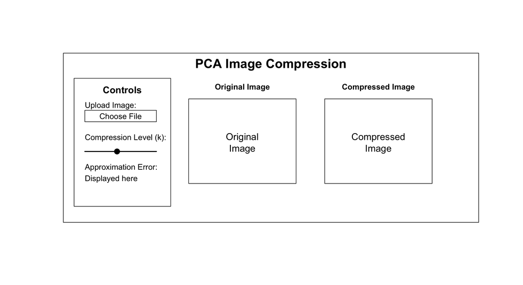

# Why I Chose This Design

I wanted the design to be simple because the main goal is comparing the original and compressed images. The controls are separated from the images so the user can easily change the settings without taking up too much space. Showing the images side by side makes the effect of changing $k$ much easier to see. The approximation error also gives the user a numerical way to compare different compression levels.

# Website Build Time

```
## [1] "2026-09-25 22:08:03 CDT"
```